# The Impact of Incarceration in Childhood on Adulthood Coping Behaviors and Health

BMIN503/EPID600 Final Project

Author

Morgan Watson

## 1 Overview

The goal of this project is to determine the association between experiencing an arrest in childhood and adverse health outcomes in adulthood. The project is focused on health outcomes, such as depression and suicidality, and adverse health behaviors. To better understand the potential relationship, the influence of certain coping mechanisms (cigarette, alcohol and marijuana use) will be assessed. The question will be addressed using publicly available Wave I and Wave IV data from the National Longitudinal Study of Adolescent to Adult Health (Add Health Study). Through discussion with Dr. Elizabeth Nesoff, I was able to specify my question to examine relevant risky behaviors and health outcomes. Additionally, I determined an analysis strategy with Dr. Nick Seewald to conduct logistic regression on my binary health and behavior outcomes.

GitHub Repository: https://github.com/moewatson/BMIN503_Final_Project

## 2 Introduction

Experience with incarceration has been associated with a variety of negative health outcomes, ranging from chronic health conditions to infectious diseases to mental health (1). It is important to understand how involvement with the justice system at critical developmental periods can impact health in adulthood. Through investigating the relationship between childhood arrest/incarceration, adverse coping mechanisms, and health outcomes, this affect can be better understood.

In 2022, there were more than 1.2 million adults detained in prison (2). There were over 420,000 youth arrests made in 2020 and more than 25,000 children under the age of 18 were held in various juvenile justice facilities (3,4). While there are fewer children involved with the justice system than adults, children experience the system at an important period of development. It is necessary to understand the potential lasting effects of the justice system given the multitude of health factors and magnitude of individuals impacted by the system. Adverse Childhood Experiences (ACEs) are potentially traumatic events which have been linked to a multitude of health outcomes. ACEs fall under three categories: Abuse (physical, emotional, or sexual), Neglect (physical or emotional), and Household Challenges (incarceration, mental illness, substance misuse or dependence, intimate partner violence, or parental separation/divorce) (5). More than 60% of US adults report experiencing at least one ACE before reaching 18 (6). Experiencing ACEs are associated with higher risk of chronic diseases, substance use, and poor mental health (4). Further, past studies have found an association between childhood arrest and increased suicidality as well as an association between childhood incarceration and worse general health (7,8). More research is needed to understand the long-lasting impacts of the carceral system on health.

This project is interdisciplinary as it ties together factors from the fields of epidemiology, criminology, and sociology to assess a complex issue. Individuals can become connected to the justice system through societal, community, interpersonal, and individual reasons. In order to determine how to effectively reduce the negative results of incarceration, interventions need to be developed which address the variety of avenues creating risk factors. Epidemiology helps to understand the magnitude of incarceration’s effect on health. Sociology provides context into how people live and the factors which impact their decisions and opportunities in life. Finally, criminology offers specific insights into the justice system and how it operates. Dr. Nesoff provided important knowledge related to how one’s neighborhood context can affect substance use and other risky behaviors. She assisted me in framing this project within the field of social epidemiology. Dr. Seewald provided helpful suggestions for my analysis, especially related to the usage of a Bonferroni correction in order to address the possibility of Type I Error when running multiple hypothesis tests within the same study.

## 3 Methods

Public-use data from the Add Health study will be analyzed below. Wave 1 data was collected in 1994-95 when participants were in grades 7-12 and first recruited into the study. Wave 4 data was collected in 2008 when participants were aged 24-32. Wave V data has been collected, but is not yet publicly available. In Wave 4, participants answered questions about criminal justice history and personal health. This data allows for information to be gathered the about experience with the justice system in childhood and current (adulthood) health. It is important to note the role of temporality in this data and subsequent analysis. In order to ensure that the health outcomes occurred after the exposure of the justice system, only questions with a time component will be considered in the final analysis. These time components include the following: “In the last 30 days”, “In the last 7 days”, “In the previous 12 months”, etc. Questions which include the wording such as, “have you ever”, will not be used for the final analysis.

In order to answer the research question, relevant demographic, exposure, and outcome variables will be selected from the original data. Any categorical variables will be recoded as factors with descriptive levels. For analysis, some variables will be dichotomized. After the cleaning of the data, various descriptive statistics will be presented through tables and figures. Finally, logistic and linear regression models will be utilized to analyze the data. Both unadjusted and adjusted models will also be presented after applying an accurate Bonferroni correction to account for potential type I error.

### 3.1 Retrieve Data

```r
library(haven)
library(tidyverse)
library(ggplot2)
library(gtsummary)
```

```r
wave1 <- read_sas("w1inhome.sas7bdat")
wave4 <- read_sas("w4inhome.sas7bdat")
```

The data for this project will utilize information from Wave 1 and Wave 4. Wave 1 includes necessary, self-reported, baseline information of participant sex and race as well as parent information (education and income) which will be used as covariates. Wave 4 includes self-reported information on criminal justice history, health history, and current health. Since this is a longitudinal analysis, demographic information from the adult participants cannot be used to also adjust for childhood experiences. For example, having a college degree as an adult (Wave 4) does not influence the likelihood of being arrested as a youth.

### 3.2 Clean Data

#### 3.2.1 Select Variables of Interest

```r
#covariate variables from wave 1 for adjusted models
w1_var <- wave1 |>
  select(AID, BIO_SEX, H1GI1M, H1GI1Y, H1GI4, H1GI6A:H1GI6E, H1RM1, H1RM5,
         H1RM9, H1RF1, H1RF5, H1RF9)

#exposure and outcome variables from wave 4
w4_var <- wave4 |>
  select(AID, BIO_SEX4, H4OD1M, H4OD1Y, H4HS1, H4ED2, H4LM11, H4EC1, H4CJ1:H4CJ5,
         H4CJ7A:H4CJ7K, H4CJ17:H4CJ20, H4GH1, H4HS9, H4ID5B:H4ID5E, H4ID5G:H4ID5J,
         H4ID5L, H4MH2:H4MH8, H4MH18:H4MH28, H4BMI, H4BMICLS, H4SE1:H4SE3, H4TO5,
         H4TO39, H4TO40, H4TO63, H4TO64A:H4TO65E, H4TO71)
```

#### 3.2.2 Recode Covariate Variables

```r
#wave 1 covariates as factors
w1_var <- w1_var |>
  mutate(age_yr = H1GI1Y,
         sex = factor(BIO_SEX, levels = c(1,2), labels = c("Male", "Female")),
         hispanic = factor(H1GI4, levels = c(0, 1), labels = c("No", "Yes")),
         race = case_when(H1GI6A == 1 ~ 1, #white
                          H1GI6B == 1 ~ 2, #black
                          H1GI6C == 1 ~ 3, #AINA
                          H1GI6D == 1 ~ 4, #asian/pacific islander
                          H1GI6E == 1 ~ 5),#other
         race = factor(race, levels = c(1:5), labels = c("White", "Black/African American",
                                                         "AI/NA", "Asian/Pacific Islander",
                                                         "Other")),
         mom_edu = case_when(H1RM1 %in% c(1,2,10) ~ 1, #less than HS
                             H1RM1 %in% c(3,6) ~ 2, #trade
                             H1RM1 %in% c(4,5) ~ 3, #HS/GED
                             H1RM1 == 7 ~ 4, #some college
                             H1RM1 %in% c(8,9) ~ 5, #college grad +
                             H1RM1 %in% c(96,97) ~ 6), #legit skip
         mom_edu = factor(mom_edu, levels = c(1:6), labels = c("Less than HS",
                                                               "Trade/Vocational",
                                                               "HS/GED", "Some College",
                                                               "College and More", "Legit Skip")),
         mom_income = factor(H1RM5, levels = c(0,1,7), labels = c("No", "Yes", "Legit Skip")),
         mom_pubasst = factor(H1RM9, levels = c(0,1,7), labels = c("No", "Yes", "Legit Skip")),
         dad_edu = case_when(H1RF1 %in% c(1,2,10) ~ 1, #less than HS
                             H1RF1 %in% c(3,6) ~ 2, #trade
                             H1RF1 %in% c(4,5) ~ 3, #HS/GED
                             H1RF1 == 7 ~ 4, #some college
                             H1RF1 %in% c(8,9) ~ 5, #college grad +
                             H1RF1 %in% c(96,97) ~ 6), #legit skip
         dad_edu = factor(dad_edu, levels = c(1:6), labels = c("Less than HS",
                                                               "Trade/Vocational",
                                                               "HS/GED", "Some College",
                                                               "College and More", "Legit Skip")),
         dad_income = factor(H1RF5, levels = c(0,1,7), labels = c("No", "Yes", "Legit Skip")),
         dad_pubasst = factor(H1RF9, levels = c(0,1,7), labels = c("No", "Yes", "Legit Skip"))
         )

w1_covar <- w1_var |>
  select(AID, age_yr:dad_pubasst)

#final cleaned wave 1 variables with missing removed
w1_comp_var <- na.omit(w1_covar)
```

Wave 1 was used to compile covariates (possible confounders). The variables of interest were respondent sex and race as well as parental (mom and dad) education, employment status, and public assistance status. For the sake of this analysis, all missing variables (those answered as “Don’t Know” or “Refused”) are removed from the analysis. A complete case analysis will be used for this project. Questions which the participant did not answer because of a “Legitimate Skip” are retained within the analysis.

#### 3.2.3 Recode Exposure Variables

```r
w4_fctvar <- w4_var |>
  mutate(insurance = case_when(H4HS1 %in% c(2:11) ~ 1,
                               H4HS1 == 1 ~ 0),
         insurance = factor(insurance, levels = c(0,1), labels = c("No", "Yes")),
         education = case_when(H4ED2 %in% c(1,2) ~ 1,
                               H4ED2 == 3 ~ 2,
                               H4ED2 %in% c(4,5) ~ 3,
                               H4ED2 == 6 ~ 4,
                               H4ED2 %in% c(7:13) ~ 5),
         education = factor(education, levels = c(1:5), labels = c("Less than HS", "HS",
                                                                   "Vocational/Tech",
                                                                   "Some College",
                                                                   "College Grad or More")),
         employment = factor(H4LM11, levels = c(0,1,7), labels = c("No", "Yes", "Legit Skip")),
         income = case_when(H4EC1 %in% c(1:6) ~ 1,
                            H4EC1 %in% c(7,8) ~ 2,
                            H4EC1 %in% c(9,10) ~ 3,
                            H4EC1 %in% c(11,12) ~ 4),
         income = factor(income, levels = c(1:4), labels = c("< 30k", "30-<50k",
                                                             "50-<100k", "100k+")),
         arrest = factor(H4CJ1, levels = c(0,1,7), labels = c("No", "Yes", "Legit Skip")),
         arrest_age = case_when(H4CJ3 %in% c(18:32) | H4CJ4 %in% c(18:29) ~ 0,
                                H4CJ3 %in% c(12:17) | H4CJ4 %in% c(10:17) ~ 1,
                                H4CJ3 == 97 | H4CJ4 == 97 ~ 2),
         arrest_agefct = factor(arrest_age, levels = c(0,1,2), labels = c("Over 18",
                                                                          "Under 18",
                                                                          "Legit Skip")),
         arrest_times = case_when(H4CJ5 == 1 ~ 1,
                                  H4CJ5 == 2 ~ 2,
                                  H4CJ5 == 3 ~ 3,
                                  H4CJ5 %in% c(4:20) ~ 4, #4 or more
                                  H4CJ5 == 997 ~ 5),
         arrest_times = factor(arrest_times, levels = c(1:5), labels = c("Once", "Twice",
                                                                         "Three",
                                                                         "Four or More",
                                                                         "Legit Skip")),
         jail = factor(H4CJ17, levels = c(0,1,7), labels = c("No", "Yes", "Legit Skip")),
         jail_age = case_when(H4CJ19 %in% c(18:32) | H4CJ20 %in% c(18:30) ~ 0,
                              H4CJ19 <= 17 | H4CJ20 <= 17 ~ 1,
                              H4CJ19 == 97 | H4CJ20 == 97 ~ 2),
         jail_agefct = factor(jail_age, levels = c(0,1,2), labels = c("Over 18",
                                                                      "Under 18",
                                                                      "Legit Skip")),
         jail_times = factor(H4CJ18, levels = c(1,2,7), labels = c("Once", "More than Once",
                                                                   "Legit Skip")),
         child_arrest_jail = case_when(arrest_age == 1 | jail_age == 1 ~ 1,
                                       arrest_age %in% c(0,2) | jail_age %in% c(0,2) ~ 0),
         child_arrest_jail = factor(child_arrest_jail, levels = c(0,1), labels = c("No", "Yes")),
         arrest_charge = case_when(H4CJ7A == 1 ~ 1, #dui
                                   H4CJ7B == 1 ~ 2, #other alcohol
                                   H4CJ7C == 1 ~ 3, #marijuana
                                   H4CJ7D == 1 ~ 4, #other drug
                                   H4CJ7E == 1 ~ 5, #robbery
                                   H4CJ7F == 1 ~ 6, #theft
                                   H4CJ7G == 1 ~ 7, #forcible rape
                                   H4CJ7H == 1 ~ 8, #aggravated assault/manslaughter/murder
                                   H4CJ7I == 1 ~ 9, #simple assault
                                   H4CJ7J == 1 ~ 10, #fraud/forgery
                                   H4CJ7K == 1 ~ 11,
                                   H4CJ7A == 7 | H4CJ7B == 7 | H4CJ7C == 7 | H4CJ7D == 7 |
                                     H4CJ7E == 7 | H4CJ7F == 7 | H4CJ7G == 7 | H4CJ7H == 7 |
                                     H4CJ7I == 7 | H4CJ7J == 7 | H4CJ7K == 7 ~ 12), #other
         arrest_charge = factor(arrest_charge, levels = c(1:12),
                                labels = c("DUI", "Other Alcohol-Related", "Marijuana",
                                           "Other Drug", "Robbery", "Theft", "Forcible Rape",
                                           "Aggravated Assault Etc", "Simple Assault",
                                           "Fraud/Forgery", "Other", "Legit Skip"))
         )
```

Any variables related to the exposure of childhood arrest/incarceration are recoded above. These variables assess both the experience of the exposure and further context of the exposure (such as the reason for arrest). Some demographic variables related to the participants at Wave 4 are included as well.

#### 3.2.4 Recode Outcome Variables

```r
w4_fctvar <- w4_fctvar |>
  mutate(health = factor(H4GH1, levels = c(1:5),
                         labels = c("Excellent", "Very Good", "Good", "Fair", "Poor")),
         health_cat = case_when(H4GH1 %in% c(1:3) ~ 1,
                                H4GH1 %in% c(4,5) ~ 0),
         health_cat = factor(health_cat, levels = c(0,1),
                             labels = c("Fair/Poor", "Excellent/Good")),
         counseling = factor(H4HS9, levels = c(0,1), labels = c("No", "Yes")),
         high_chol = factor(H4ID5B, levels = c(0,1), labels = c("No", "Yes")),
         high_bp = factor(H4ID5C, levels = c(0,1), labels = c("No", "Yes")),
         diabetes = factor(H4ID5D, levels = c(0,1), labels = c("No", "Yes")),
         heart_disease = factor(H4ID5E, levels = c(0,1), labels = c("No", "Yes")),
         migraine = factor(H4ID5G, levels = c(0,1), labels = c("No", "Yes")),
         depression = factor(H4ID5H, levels = c(0,1), labels = c("No", "Yes")),
         ptsd = factor(H4ID5I, levels = c(0,1), labels = c("No", "Yes")),
         anxiety = factor(H4ID5J, levels = c(0,1), labels = c("No", "Yes")),
         adhd = factor(H4ID5L, levels = c(0,1), labels = c("No", "Yes")),
         bmi = H4BMI,
         bmi_cat = factor(H4BMICLS, levels = c(1:6),
                          labels = c("Underweight: <18.5", "Normal: 18.5-<25",
                                     "Overweight: 25-<30",
                                     "Obese I: 30-<35", "Obese II: 35-<40", "Obese III: 40+")),
         self_intelligent = case_when(H4MH7 %in% c(1,2) ~ 1,
                                      H4MH7 == 3 ~ 2,
                                      H4MH7 %in% c(4:6) ~ 3),
         self_intelligent = factor(self_intelligent, levels = c(1,2,3),
                                   labels = c("Below Avg", "Average", "Above Avg")),
         self_int_dich = case_when(H4MH7 %in% c(1,2) ~ 0,
                                   H4MH7 %in% c(3:6) ~ 1),
         self_int_dich = factor(self_int_dich, levels = c(0,1),
                                labels = c("Below Avg", "Avg and Above")),
         self_attractive = factor(H4MH8, levels = c(1:4),
                                  labels = c("Very", "Moderately", "Slightly", "Not at All")),
         self_attr_dich = case_when(H4MH8 %in% c(1:3) ~ 1,
                                    H4MH8 == 4 ~ 0),
         self_attr_dich = factor(self_attr_dich, levels = c(0,1),
                                 labels = c("Unattractive", "Attractive")),
         suicide_thoughts = factor(H4SE1, levels = c(0,1), labels = c("No", "Yes")),
         suicide_attempt = case_when(H4SE2 == 0 ~ 0,
                                     H4SE2 == 1 ~ 1,
                                     H4SE2 %in% c(2:4) ~ 2,
                                     H4SE2 == 7 ~ 3),
         suicide_attempt = factor(suicide_attempt, levels = c(0:3),
                                  labels = c("None", "Once", "Two or More", "Legit Skip")),
         sui_attempt_dich = case_when(H4SE2 == 0 ~ 0,
                                       H4SE2 %in% c(1:4) ~ 1),
         sui_attempt_dich = factor(sui_attempt_dich, levels = c(0,1),
                                   labels = c("None", "One or More")),
         suicide_treat = factor(H4SE3, levels = c(0,1,7), labels = c("No", "Yes", "Legit Skip")),
         cig_days = case_when(H4TO5 == 0 ~ 0,
                              H4TO5 %in% c(1:10) ~ 1,
                              H4TO5 %in% c(11:20) ~ 2,
                              H4TO5 %in% c(21:29) ~ 3,
                              H4TO5 == 30 ~ 4),
         cig_days = factor(cig_days, levels = c(0:4),
                           labels = c("None", "Occasional", "Regular", "Heavy", "Daily")),
         cig_dich = case_when(cig_days %in% c("None") ~ 0,
                              cig_days %in% c("Occasional", "Regular", "Heavy", "Daily") ~ 1),
         cig_dich = factor(cig_dich, levels = c(0,1), labels = c("No", "Yes")),
         alcohol_days = case_when(H4TO39 == 0 | H4TO39 == 97 ~ 0,
                                  H4TO39 %in% c(1,2) ~ 1,
                                  H4TO39 %in% c(3,4) ~ 2,
                                  H4TO39 == 5 ~ 3,
                                  H4TO39 == 6 ~ 4),
         alcohol_days = factor(alcohol_days, levels = c(0:4),
                               labels = c("None", "Occasional", "Regular", "Heavy", "Daily")),
         alc_dich = case_when(alcohol_days %in% c("None") ~ 0,
                              alcohol_days %in% c("Occasional", "Regular", "Heavy", "Daily") ~ 1),
         alc_dich = factor(alc_dich, levels = c(0,1), labels = c("No", "Yes")),
         prescript_drugs = factor(H4TO63, levels = c(0,1), labels = c("No", "Yes")),
         prescript_drug_type = case_when(H4TO64A == 1 ~ 1, #sedative
                                         H4TO64B == 1 ~ 2, #tranq
                                         H4TO64C == 1 ~ 3, #stimulant
                                         H4TO64D == 1 ~ 4,
                                         H4TO64A == 7 | H4TO64B == 7 |
                                           H4TO64C == 7 | H4TO64D == 7 ~ 5), #pain killer
         prescript_drug_type = factor(prescript_drug_type, levels = c(1:5),
                                      labels = c("Sedative", "Tranquilizer", "Stimulant",
                                                 "Pain Killer", "Legit Skip")),
         marijuana = factor(H4TO65B, levels = c(0,1), labels = c("No", "Yes")),
         cocaine = factor(H4TO65C, levels = c(0,1), labels = c("No", "Yes")),
         crystal_meth = factor(H4TO65B, levels = c(0,1), labels = c("No", "Yes")),
         other = factor(H4TO65B, levels = c(0,1), labels = c("No", "Yes")),
         mari_days = case_when(H4TO71 == 0 | H4TO71 == 97 ~ 0,
                               H4TO71 %in% c(1,2) ~ 1,
                               H4TO71 %in% c(3,4) ~ 2,
                               H4TO71 == 5 ~ 3,
                               H4TO71 == 6 ~ 4),
         mari_days = factor(mari_days, levels = c(0:4),
                            labels = c("None", "Occasional", "Regular", "Heavy", "Daily")),
         mari_dich = case_when(mari_days %in% c("None") ~ 0,
                              mari_days %in% c("Occasional", "Regular", "Heavy", "Daily") ~ 1),
         mari_dich = factor(mari_dich, levels = c(0,1), labels = c("No", "Yes"))
         )

#create depressive symptoms score based on CESD
w4_fctvar <- w4_fctvar |>
  mutate(bothered = case_when(H4MH18 == 0 ~ 0,
                              H4MH18 == 1 ~ 1,
                              H4MH18 == 2 ~ 2,
                              H4MH18 == 3 ~ 3),
         blues = case_when(H4MH19 == 0 ~ 0,
                           H4MH19 == 1 ~ 1,
                           H4MH19 == 2 ~ 2,
                           H4MH19 == 3 ~ 3),
         asgood = case_when(H4MH20 == 0 ~ 3,
                            H4MH20 == 1 ~ 2,
                            H4MH20 == 2 ~ 1,
                            H4MH20 == 3 ~ 0), #reverse
         troublemind = case_when(H4MH21 == 0 ~ 0,
                                 H4MH21 == 1 ~ 1,
                                 H4MH21 == 2 ~ 2,
                                 H4MH21 == 3 ~ 3),
         depress = case_when(H4MH22 == 0 ~ 0,
                             H4MH22 == 1 ~ 1,
                             H4MH22 == 2 ~ 2,
                             H4MH22 == 3 ~ 3),
         tired = case_when(H4MH23 == 0 ~ 0,
                           H4MH23 == 1 ~ 1,
                           H4MH23 == 2 ~ 2,
                           H4MH23 == 3 ~ 3),
         happy = case_when(H4MH24 == 0 ~ 3,
                           H4MH24 == 1 ~ 2,
                           H4MH24 == 2 ~ 1,
                           H4MH24 == 3 ~ 0), #reverse
         enjoylife = case_when(H4MH25 == 0 ~ 3,
                              H4MH25 == 1 ~ 2,
                              H4MH25 == 2 ~ 1,
                              H4MH25 == 3 ~ 0), #reverse
         sad = case_when(H4MH26 == 0 ~ 0,
                         H4MH26 == 1 ~ 1,
                         H4MH26 == 2 ~ 2,
                         H4MH26 == 3 ~ 3),
         ppldislike = case_when(H4MH27 == 0 ~ 0,
                                H4MH27 == 1 ~ 1,
                                H4MH27 == 2 ~ 2,
                                H4MH27 == 3 ~ 3)
         )

w4_fctvar <- w4_fctvar |>
  select(AID, insurance:ppldislike)

#the final cleaned data with no missing and the inclusion of the depressive symptoms score
w4_comp_fctvar <- na.omit(w4_fctvar) |>
  mutate(dep_symp = rowSums(across(c(bothered, blues, asgood, troublemind, depress,
                                     tired, happy, enjoylife, sad, ppldislike))),
         cesd = case_when(dep_symp < 11 ~ 0,
                          dep_symp >= 11 ~ 1),
         cesd = factor(cesd, levels = c(0,1), labels = c("No", "Yes"))
         )
```

The necessary outcome variables are recoded above. While there are many variables related to health and health behaviors, the regression analysis will be focused on only those for which temporality can be established. Specifically, questions in the Wave 4 questionnaire worded as “have you ever been told by a doctor” will not be included in the ultimate analysis because it is unknown when the diagnosis occurred. Instead, variables which asked about health outcomes within the past 30 days, or past 7 days for depression, will be used to assess the longitudinal relationship between childhood arrest/incarceration and adulthood health. Since most of the outcome variables are categorical, the ones which will be used in the analysis have been dichotomized so that logistic regression can be conducted. The outcome variables which will be used in the final analysis are: general health, BMI, counseling status, depressive symptoms (based on the CESD-10), suicidal thoughts, use of the cigarettes/alcohol/marijuana in the last 30 days.

#### 3.2.5 Analysis Dataset

```r
final_data <- merge(w1_comp_var, w4_comp_fctvar, by = "AID")

#relevels the arrest and jail age factor variables so that legit skip is the reference
final_data$arrest_agefct <- relevel(final_data$arrest_agefct, ref = "Legit Skip")
final_data$jail_agefct <- relevel(final_data$jail_agefct, ref = "Legit Skip")
```

The final analysis dataset is created above. It includes all recoded and cleaned relevant variables from Waves 1 and 4.

### 3.3 Descriptive Statistics

#### 3.3.1 Demographic Variables

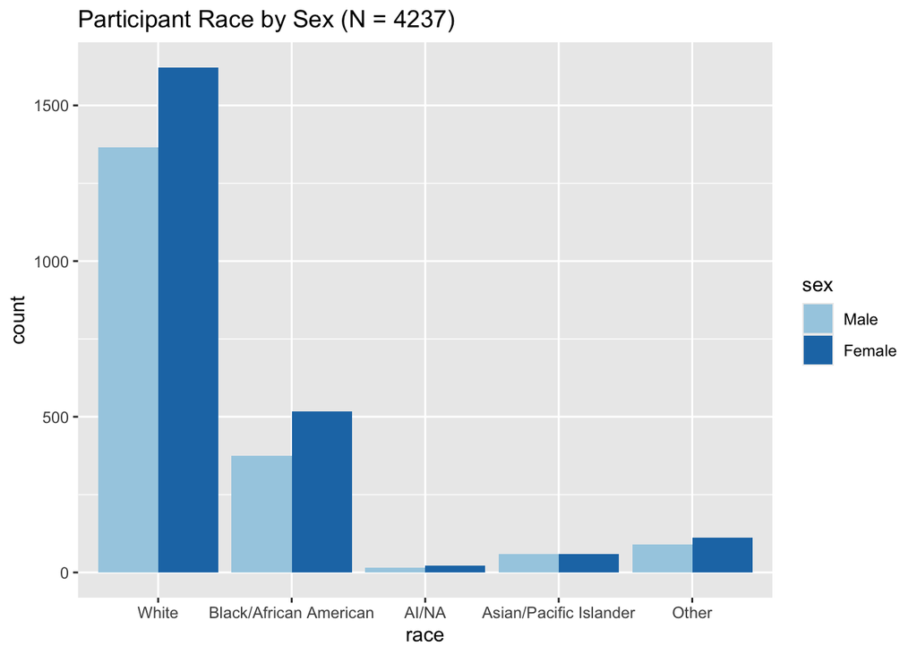

```r
#sex, race, ethnicity, education, employment, income, insurance

ggplot(final_data, aes(race, fill = sex)) + geom_bar(position = "dodge") + scale_fill_brewer(palette = "Paired") + ggtitle("Participant Race by Sex (N = 4237)")
```

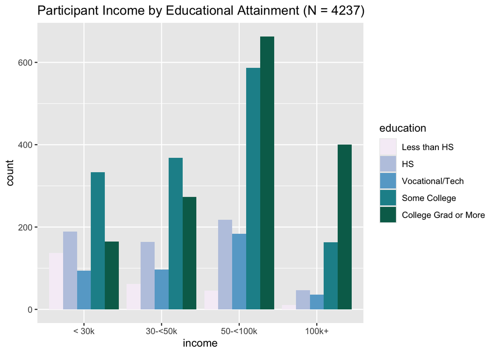

```r
ggplot(final_data, aes(income, fill = education)) + geom_bar(position = "dodge") + scale_fill_brewer(palette = "PuBuGn") + ggtitle("Participant Income by Educational Attainment (N = 4237)")
```

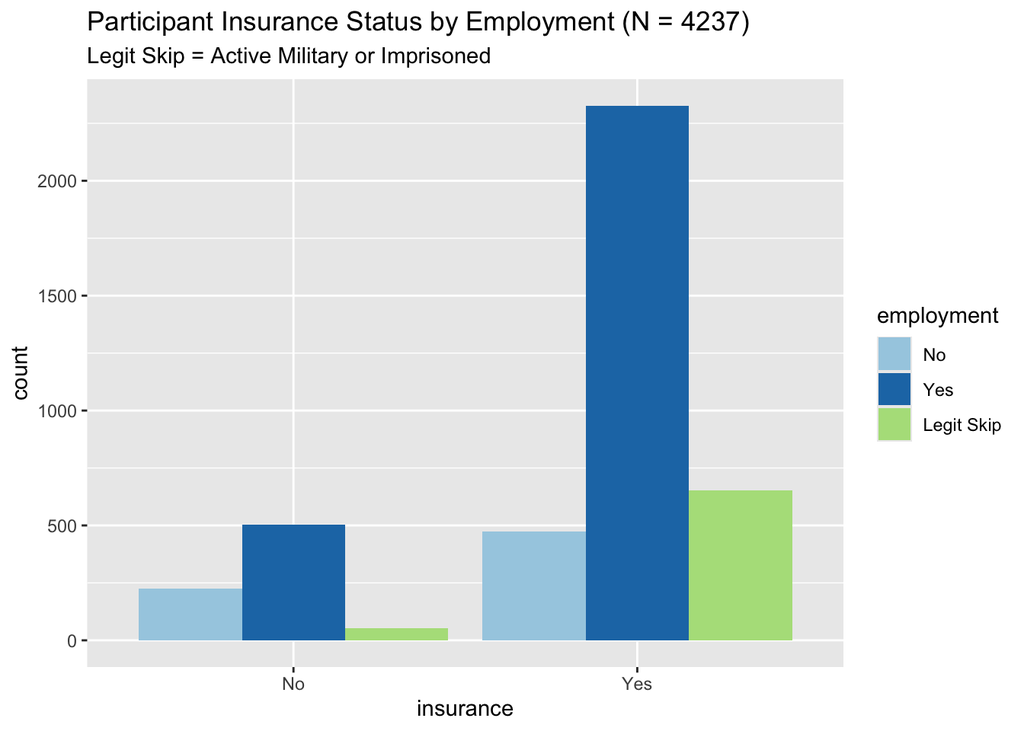

```r
ggplot(final_data, aes(insurance, fill = employment)) + geom_bar(position = "dodge") + scale_fill_brewer(palette = "Paired") + ggtitle("Participant Insurance Status by Employment (N = 4237)") + labs(subtitle = "Legit Skip = Active Military or Imprisoned") #employ legit skip is military or in prison
```

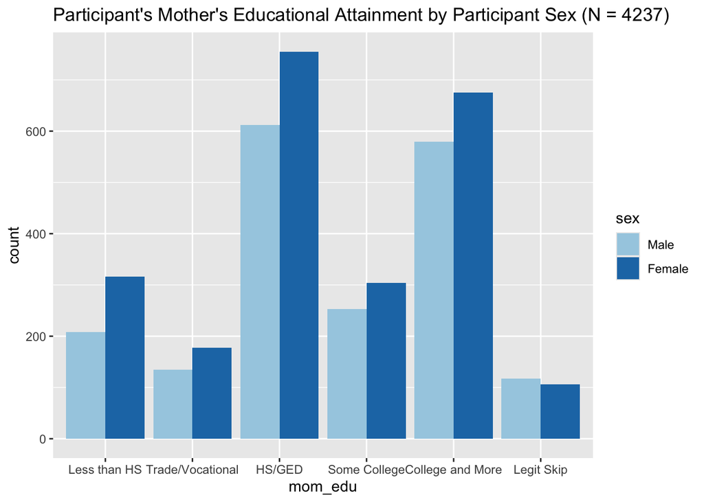

```r
ggplot(final_data, aes(mom_edu, fill = sex)) + geom_bar(position = "dodge") + scale_fill_brewer(palette = "Paired") + ggtitle("Participant's Mother's Educational Attainment by Participant Sex (N = 4237)")
```

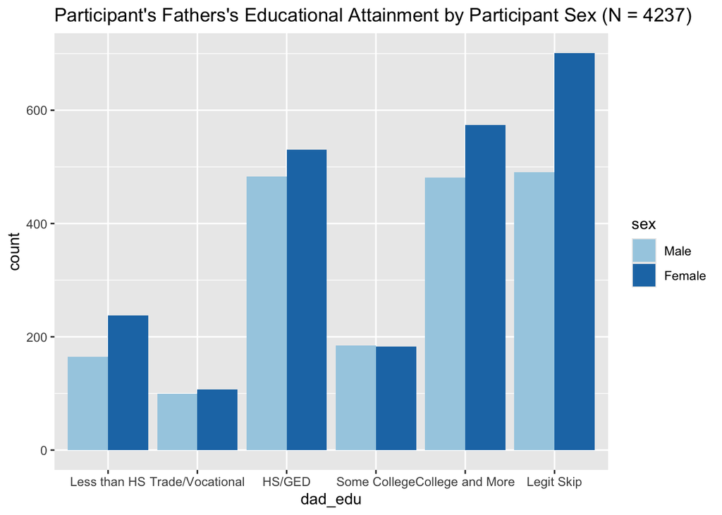

```r
ggplot(final_data, aes(dad_edu, fill = sex)) + geom_bar(position = "dodge") + scale_fill_brewer(palette = "Paired") + ggtitle("Participant's Fathers's Educational Attainment by Participant Sex (N = 4237)")
```